# Práctica 4: Ecología Espacial y Conservación

Análisis de Metapoblaciones y Fragmentación de Hábitat

2025-11-12

# Introducción

En esta práctica analizarás un sistema de metapoblaciones en un paisaje fragmentado. Trabajarás con datos de parches de bosque para entender conceptos clave de ecología espacial y conservación.

# Parte 1: Carga de Datos y Exploración

## 1.1 Cargar librerías necesarias

```r
# Instalar si es necesario: install.packages(c("tidyverse", "ggplot2", "vegan"))
library(tidyverse)
library(ggplot2)
library(vegan)

# Establecer semilla para reproducibilidad
# IMPORTANTE: Cambia este número por tu escenario asignado (1-30)
escenario <- 1  # <-- CAMBIA ESTE NÚMERO
set.seed(escenario * 100)
```

## 1.2 Generar tus datos únicos

```r
# Número de parches de bosque en el paisaje
n_parches <- sample(8:15, 1)

# Generar datos de parches
datos_parches <- data.frame(
  parche_id = 1:n_parches,
  area_ha = round(runif(n_parches, 5, 150), 1),
  ocupado = sample(c(TRUE, FALSE), n_parches, replace = TRUE, prob = c(0.6, 0.4)),
  distancia_mas_cercano_km = round(runif(n_parches, 0.5, 8), 2),
  calidad_habitat = sample(c("Alta", "Media", "Baja"), n_parches, replace = TRUE),
  heterocigosidad = round(runif(n_parches, 0.35, 0.85), 3),
  riqueza_especies = round(rnorm(n_parches, mean = 25, sd = 8))
)

# Ajustar heterocigosidad según área (efecto cuello de botella)
datos_parches$heterocigosidad <- datos_parches$heterocigosidad *
  (0.7 + 0.3 * (datos_parches$area_ha / max(datos_parches$area_ha)))
datos_parches$heterocigosidad <- round(pmin(datos_parches$heterocigosidad, 0.85), 3)

# Ajustar riqueza según área (relación especies-área)
datos_parches$riqueza_especies <- round(15 + 10 * log10(datos_parches$area_ha + 1))
datos_parches$riqueza_especies <- pmax(datos_parches$riqueza_especies, 5)

# Mostrar datos
print(datos_parches)
```

```
##   parche_id area_ha ocupado distancia_mas_cercano_km calidad_habitat
## 1         1    42.4   FALSE                     5.68           Media
## 2         2    85.1   FALSE                     4.52            Alta
## 3         3    13.2    TRUE                     5.83           Media
## 4         4    72.9    TRUE                     4.54            Baja
## 5         5    75.1   FALSE                     6.12           Media
## 6         6   122.8   FALSE                     3.65            Alta
## 7         7    58.7    TRUE                     1.79            Baja
## 8         8    84.3    TRUE                     6.28            Baja
## 9         9    29.7    TRUE                     7.11            Alta
##   heterocigosidad riqueza_especies
## 1           0.594               31
## 2           0.694               34
## 3           0.477               27
## 4           0.523               34
## 5           0.654               34
## 6           0.792               36
## 7           0.383               33
## 8           0.457               34
## 9           0.398               30
```

```r
# Guardar para referencia
write.csv(datos_parches, paste0("escenario_", escenario, "_datos.csv"), row.names = FALSE)
```

“Ocupado” = ¿Tiene población presente? En el contexto de metapoblaciones:

TRUE (ocupado): El parche de bosque tiene una población local de una especie de interés presente en ese momento FALSE (desocupado): El parche de bosque no tiene la especie de interés, pero es hábitat habitable

## 1.3 Visualizar el paisaje

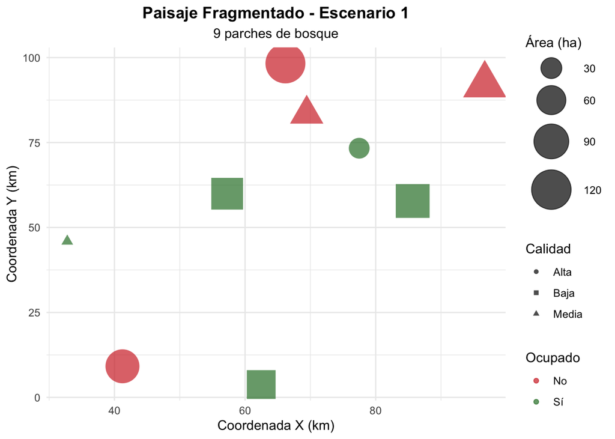

```r
# Generar coordenadas espaciales para los parches
coords <- data.frame(
  x = runif(n_parches, 0, 100),
  y = runif(n_parches, 0, 100)
)

datos_parches <- cbind(datos_parches, coords)

# Gráfico del paisaje
ggplot(datos_parches, aes(x = x, y = y)) +
  geom_point(aes(size = area_ha, color = ocupado, shape = calidad_habitat), alpha = 0.7) +
  scale_size_continuous(range = c(3, 15), name = "Área (ha)") +
  scale_color_manual(values = c("TRUE" = "#2E7D32", "FALSE" = "#D32F2F"),
                     name = "Ocupado",
                     labels = c("No", "Sí")) +
  scale_shape_manual(values = c("Alta" = 16, "Media" = 17, "Baja" = 15),
                     name = "Calidad") +
  labs(title = paste("Paisaje Fragmentado - Escenario", escenario),
       subtitle = paste(n_parches, "parches de bosque"),
       x = "Coordenada X (km)", y = "Coordenada Y (km)") +
  theme_minimal() +
  theme(plot.title = element_text(hjust = 0.5, face = "bold"),
        plot.subtitle = element_text(hjust = 0.5))
```

**PREGUNTA 1:** Describe brevemente el patrón espacial de tu paisaje. ¿Los parches están agrupados o dispersos?

*Tu respuesta:*

# Parte 2: Análisis de Metapoblaciones

## 2.1 Calcular métricas de metapoblación

```r
# Proporción de parches ocupados
prop_ocupados <- mean(datos_parches$ocupado)

# Área total y área ocupada
area_total <- sum(datos_parches$area_ha)
area_ocupada <- sum(datos_parches$area_ha[datos_parches$ocupado])

# Tamaño promedio de parches ocupados vs desocupados
tam_ocupados <- mean(datos_parches$area_ha[datos_parches$ocupado])
tam_desocupados <- mean(datos_parches$area_ha[!datos_parches$ocupado])

# Distancia promedio entre parches
dist_promedio <- mean(datos_parches$distancia_mas_cercano_km)

# Resumen
cat("=== MÉTRICAS DE LA METAPOBLACIÓN ===\n")
```

```
## === MÉTRICAS DE LA METAPOBLACIÓN ===
```

```r
cat("Proporción de parches ocupados:", round(prop_ocupados * 100, 1), "%\n")
```

```
## Proporción de parches ocupados: 55.6 %
```

```r
cat("Área total del paisaje:", area_total, "ha\n")
```

```
## Área total del paisaje: 584.2 ha
```

```r
cat("Área ocupada:", round(area_ocupada, 1), "ha\n")
```

```
## Área ocupada: 258.8 ha
```

```r
cat("Tamaño promedio parches ocupados:", round(tam_ocupados, 1), "ha\n")
```

```
## Tamaño promedio parches ocupados: 51.8 ha
```

```r
cat("Tamaño promedio parches desocupados:", round(tam_desocupados, 1), "ha\n")
```

```
## Tamaño promedio parches desocupados: 81.3 ha
```

```r
cat("Distancia promedio al parche más cercano:", round(dist_promedio, 2), "km\n")
```

```
## Distancia promedio al parche más cercano: 5.06 km
```

## 2.2 Modelo de colonización y extinción

Según la teoría de metapoblaciones, la probabilidad de colonización aumenta con el área del parche y disminuye con la distancia. La probabilidad de extinción disminuye con el área.

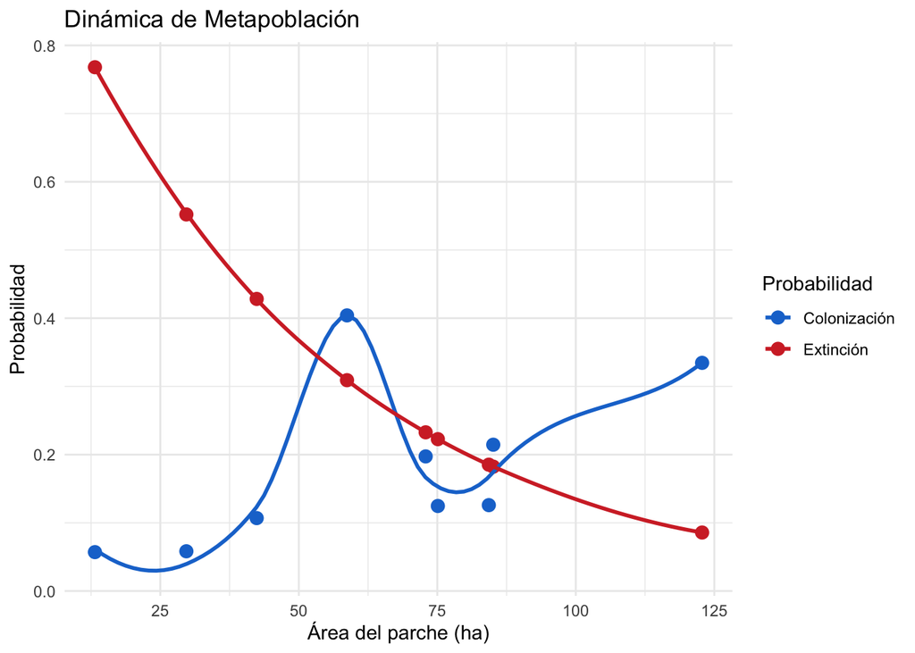

```r
# Calcular probabilidad de colonización (función del área y distancia)
# P(colonización) = e^(-distancia * 0.3) * (área / área_max)^0.5
datos_parches$prob_colonizacion <-
  exp(-datos_parches$distancia_mas_cercano_km * 0.3) *
  sqrt(datos_parches$area_ha / max(datos_parches$area_ha))

# Calcular probabilidad de extinción (función inversa del área)
# P(extinción) = e^(-área / 50)
datos_parches$prob_extincion <- exp(-datos_parches$area_ha / 50)

# Visualizar
datos_long <- datos_parches %>%
  select(parche_id, area_ha, prob_colonizacion, prob_extincion) %>%
  pivot_longer(cols = c(prob_colonizacion, prob_extincion),
               names_to = "Probabilidad", values_to = "Valor")

ggplot(datos_long, aes(x = area_ha, y = Valor, color = Probabilidad)) +
  geom_point(size = 3) +
  geom_smooth(method = "loess", se = FALSE) +
  scale_color_manual(values = c("#1976D2", "#D32F2F"),
                     labels = c("Colonización", "Extinción")) +
  labs(title = "Dinámica de Metapoblación",
       x = "Área del parche (ha)",
       y = "Probabilidad") +
  theme_minimal()
```

prob_colonizacion (0.0 - 1.0)

Probabilidad de que un parche desocupado sea colonizado por dispersores.

0.0-0.2 = Muy difícil de colonizar (lejos y/o pequeño) 0.2-0.5 = Dificultad media 0.5-0.8 = Fácil de colonizar (cerca y/o grande) 0.8-1.0 = Muy fácil de colonizar

prob_extincion (0.0 - 1.0)

Probabilidad de que la población local en un parche se extinga.

0.0-0.2 = Muy estable (extinción improbable) 0.2-0.4 = Riesgo moderado 0.4-0.7 = Alto riesgo de extinción 0.7-1.0 = Extinción casi segura

**PREGUNTA 2:** ¿Qué relación observas entre el área del parche y las probabilidades de colonización/extinción?

*Tu respuesta:*

**PREGUNTA 3:** Según estos resultados, ¿qué parches (grandes o pequeños) son más importantes para la persistencia de la metapoblación? ¿Por qué?

*Tu respuesta:*

# Parte 3: Efectos de Fragmentación y Genética

## 3.1 Análisis de diversidad genética

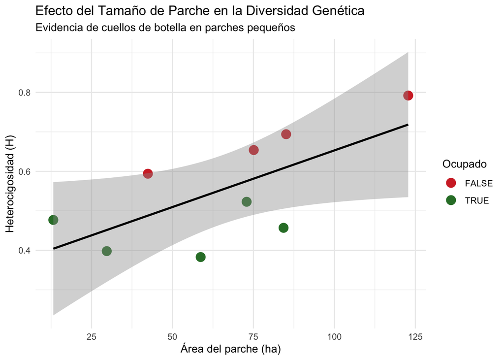

```r
# Relación área-heterocigosidad (efecto cuello de botella)
ggplot(datos_parches, aes(x = area_ha, y = heterocigosidad)) +
  geom_point(aes(color = ocupado), size = 4) +
  geom_smooth(method = "lm", se = TRUE, color = "black") +
  scale_color_manual(values = c("TRUE" = "#2E7D32", "FALSE" = "#D32F2F"),
                     name = "Ocupado") +
  labs(title = "Efecto del Tamaño de Parche en la Diversidad Genética",
       subtitle = "Evidencia de cuellos de botella en parches pequeños",
       x = "Área del parche (ha)",
       y = "Heterocigosidad (H)") +
  theme_minimal()
```

```r
# Correlación
cor_area_het <- cor(datos_parches$area_ha, datos_parches$heterocigosidad)
cat("\nCorrelación área-heterocigosidad:", round(cor_area_het, 3), "\n")
```

```
##
## Correlación área-heterocigosidad: 0.676
```

```r
# Comparar heterocigosidad por tamaño
datos_parches$categoria_tamano <- cut(datos_parches$area_ha,
                                       breaks = c(0, 30, 70, Inf),
                                       labels = c("Pequeño", "Mediano", "Grande"))

het_por_tamano <- datos_parches %>%
  group_by(categoria_tamano) %>%
  summarise(heterocigosidad_promedio = mean(heterocigosidad),
            n = n())

print(het_por_tamano)
```

```
## # A tibble: 3 × 3
##   categoria_tamano heterocigosidad_promedio     n
##   <fct>                               <dbl> <int>
## 1 Pequeño                             0.438     2
## 2 Mediano                             0.488     2
## 3 Grande                              0.624     5
```

Heterocigosidad (0.0 - 0.85)

Un índice de diversidad genética dentro de la población del parche. Mide qué tan variados son los genes de los individuos.

**PREGUNTA 4:** ¿Qué evidencia encuentras de cuellos de botella genéticos en este paisaje? Explica usando tus resultados.

*Tu respuesta:*

**PREGUNTA 5:** ¿Por qué la deriva genética es más fuerte en poblaciones pequeñas? ¿Qué consecuencias tiene esto para la conservación?

*Tu respuesta:*

## 3.2 Relación especies-área

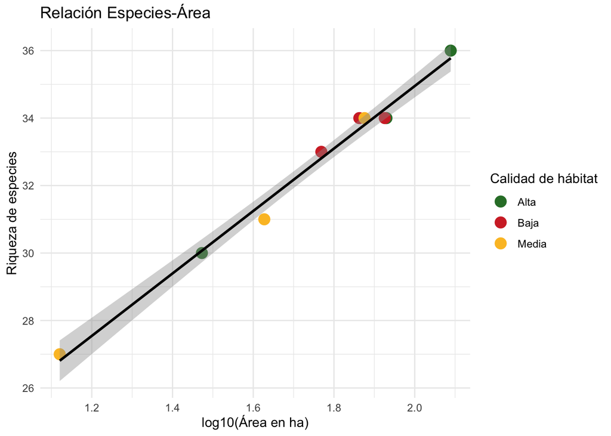

```r
# Gráfico especies-área
ggplot(datos_parches, aes(x = log10(area_ha), y = riqueza_especies)) +
  geom_point(aes(color = calidad_habitat), size = 4) +
  geom_smooth(method = "lm", se = TRUE, color = "black") +
  scale_color_manual(values = c("Alta" = "#2E7D32", "Media" = "#FBC02D", "Baja" = "#D32F2F")) +
  labs(title = "Relación Especies-Área",
       x = "log10(Área en ha)",
       y = "Riqueza de especies",
       color = "Calidad de hábitat") +
  theme_minimal()
```

```r
# Modelo lineal
modelo_SAR <- lm(riqueza_especies ~ log10(area_ha), data = datos_parches)
cat("\n=== MODELO ESPECIES-ÁREA ===\n")
```

```
##
## === MODELO ESPECIES-ÁREA ===
```

```r
print(summary(modelo_SAR))
```

```
##
## Call:
## lm(formula = riqueza_especies ~ log10(area_ha), data = datos_parches)
##
## Residuals:
##     Min      1Q  Median      3Q     Max
## -0.4997 -0.2630  0.1923  0.2017  0.3212
##
## Coefficients:
##                Estimate Std. Error t value Pr(>|t|)
## (Intercept)     16.4329     0.6606   24.88 4.33e-08 ***
## log10(area_ha)   9.2584     0.3746   24.71 4.53e-08 ***
## ---
## Signif. codes:  0 '***' 0.001 '**' 0.01 '*' 0.05 '.' 0.1 ' ' 1
##
## Residual standard error: 0.3122 on 7 degrees of freedom
## Multiple R-squared:  0.9887, Adjusted R-squared:  0.9871
## F-statistic: 610.8 on 1 and 7 DF,  p-value: 4.526e-08
```

```r
# Predicción: pérdida de especies con reducción de área
perdida_50 <- predict(modelo_SAR, newdata = data.frame(area_ha = datos_parches$area_ha)) -
              predict(modelo_SAR, newdata = data.frame(area_ha = datos_parches$area_ha * 0.5))
cat("\nPérdida promedio de especies si el área se reduce 50%:", round(mean(perdida_50), 1), "especies\n")
```

```
##
## Pérdida promedio de especies si el área se reduce 50%: 2.8 especies
```

**PREGUNTA 6:** Si se perdiera el 50% del área de cada parche por deforestación, ¿cuántas especies se perderían en promedio? ¿Qué implicaciones tiene esto?

*Tu respuesta:*

# Parte 4: Conectividad y Estrategias de Conservación

## 4.1 Análisis de conectividad

```r
# Identificar parches críticos (grandes y con alta calidad)
datos_parches$criticidad <-
  (datos_parches$area_ha / max(datos_parches$area_ha)) * 0.5 +
  (datos_parches$calidad_habitat == "Alta") * 0.3 +
  (datos_parches$ocupado) * 0.2

# Ordenar por criticidad
parches_criticos <- datos_parches %>%
  arrange(desc(criticidad)) %>%
  select(parche_id, area_ha, calidad_habitat, ocupado, distancia_mas_cercano_km, criticidad)

cat("=== PARCHES CRÍTICOS PARA CONSERVACIÓN ===\n")
```

```
## === PARCHES CRÍTICOS PARA CONSERVACIÓN ===
```

```r
print(head(parches_criticos, 5))
```

```
##   parche_id area_ha calidad_habitat ocupado distancia_mas_cercano_km criticidad
## 1         6   122.8            Alta   FALSE                     3.65  0.8000000
## 2         2    85.1            Alta   FALSE                     4.52  0.6464984
## 3         9    29.7            Alta    TRUE                     7.11  0.6209283
## 4         8    84.3            Baja    TRUE                     6.28  0.5432410
## 5         4    72.9            Baja    TRUE                     4.54  0.4968241
```

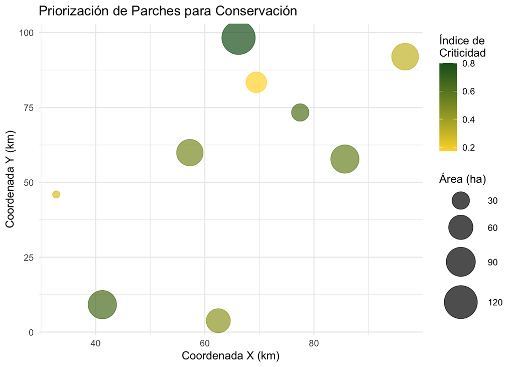

```r
# Visualizar conectividad
ggplot(datos_parches, aes(x = x, y = y)) +
  geom_point(aes(size = area_ha, color = criticidad), alpha = 0.7) +
  scale_size_continuous(range = c(3, 15), name = "Área (ha)") +
  scale_color_gradient(low = "#FDD835", high = "#1B5E20", name = "Índice de\nCriticidad") +
  labs(title = "Priorización de Parches para Conservación",
       x = "Coordenada X (km)", y = "Coordenada Y (km)") +
  theme_minimal()
```

criticidad (0.0 - 1.0)

Un índice compuesto que indica qué tan importante es el parche para conservación. Combina múltiples factores en un solo número.

0.0-0.3 = Baja prioridad para conservación 0.3-0.6 = Prioridad media 0.6-0.8 = Alta prioridad 0.8-1.0 = Prioridad crítica (DEBE protegerse)

## 4.2 Proponer corredores biológicos

```r
# Identificar pares de parches que necesitan conectividad
# (parches ocupados separados por > 3 km)
parches_ocupados <- datos_parches %>% filter(ocupado == TRUE)

necesidad_corredor <- parches_ocupados %>%
  filter(distancia_mas_cercano_km > 3) %>%
  arrange(desc(area_ha))

cat("\n=== PARCHES QUE NECESITAN CORREDORES ===\n")
```

```
##
## === PARCHES QUE NECESITAN CORREDORES ===
```

```r
cat("Número de parches aislados (>3 km):", nrow(necesidad_corredor), "\n\n")
```

```
## Número de parches aislados (>3 km): 4
```

```r
if(nrow(necesidad_corredor) > 0) {
  print(necesidad_corredor %>% select(parche_id, area_ha, distancia_mas_cercano_km))
}
```

```
##   parche_id area_ha distancia_mas_cercano_km
## 1         8    84.3                     6.28
## 2         4    72.9                     4.54
## 3         9    29.7                     7.11
## 4         3    13.2                     5.83
```

**PREGUNTA 7:** Basándote en tus análisis, ¿cuáles son los 3 parches más importantes para conservar y por qué?

*Tu respuesta:*

**PREGUNTA 8:** ¿Qué estrategia de conservación recomendarías para este paisaje? Considera: protección de parches, corredores, restauración, etc.

*Tu respuesta:*

# Parte 5: Síntesis y Contexto local

## 5.1 Aplicación al contexto local

La República Dominicana posee una extraordinaria biodiversidad con alto endemismo, pero enfrenta amenazas por:

- Deforestación para agricultura y desarrollo urbano
- Fragmentación de bosques
- Pérdida de manglares y arrecifes coralinos
- Presión sobre áreas protegidas

```r
# Resumen final de tu paisaje
cat("=== RESUMEN DE TU PAISAJE (Escenario", escenario, ") ===\n\n")
```

```
## === RESUMEN DE TU PAISAJE (Escenario 1 ) ===
```

```r
cat("Número total de parches:", n_parches, "\n")
```

```
## Número total de parches: 9
```

```r
cat("Porcentaje de paisaje ocupado:", round(prop_ocupados * 100, 1), "%\n")
```

```
## Porcentaje de paisaje ocupado: 55.6 %
```

```r
cat("Conectividad promedio:", round(1 / mean(datos_parches$distancia_mas_cercano_km), 2),
    "(inverso de distancia)\n")
```

```
## Conectividad promedio: 0.2 (inverso de distancia)
```

```r
cat("Diversidad genética promedio:", round(mean(datos_parches$heterocigosidad), 3), "\n")
```

```
## Diversidad genética promedio: 0.552
```

```r
cat("Riqueza promedio:", round(mean(datos_parches$riqueza_especies), 1), "especies\n")
```

```
## Riqueza promedio: 32.6 especies
```

```r
# Estado de conservación
if(prop_ocupados > 0.7 & mean(datos_parches$distancia_mas_cercano_km) < 4) {
  cat("\nESTADO: Relativamente bien conectado\n")
} else if(prop_ocupados > 0.5) {
  cat("\nESTADO: Moderadamente fragmentado - requiere intervención\n")
} else {
  cat("\nESTADO: Altamente fragmentado - necesita acción urgente\n")
}
```

```
##
## ESTADO: Moderadamente fragmentado - requiere intervención
```

**PREGUNTA 9:** ¿Cómo se relacionan los problemas de tu paisaje simulado con los problemas reales de conservación en República Dominicana?

*Tu respuesta:*

**PREGUNTA 10:** Propón UNA medida específica y práctica que podría implementarse en RD para mejorar la conectividad del paisaje.

*Tu respuesta:*

# Conclusiones

Resume en un párrafo los conceptos más importantes que aprendiste en esta práctica sobre ecología espacial y conservación:

*Tu respuesta:*